# Homework 6

Steve Harms

April 6, 2019

## 1. Consider a simple version of functional data regression on the `fbiwide` data in `classdata` package. Drop the variable `Rape` due to too many missing values.

### (a) Use the log transformation of `crime counts over Population` (expect `Rape`) as response. Use $State$, $Year - 1961$, $(Year - 1961)^2$, $(Year - 1961)^3$ as covariates. Fit the regression model and output the anova analysis results for each covariate. (Delete the obervations with missing values in the data, after dropping the variable `Rape`.)

```r
#transform the data to log population
fbi <- fbiwide %>% select(-Rape) %>%
  mutate_at(vars(5:11), funs(./Population)) %>% mutate_at(5:11, funs(log(.)))
#get covariates
fbi <- fbi %>% mutate(Y.1 = Year-1961, Y.2=(Y.1)^2, Y.3=(Y.1)^3)
#drop NAs
fbi <- fbi %>% filter(complete.cases(.))


#regression model and MANOVA
fit.lm <- lm(cbind(fbi %>% select(5:11) %>% as.matrix()) ~ Y.1 + Y.2 + Y.3 + as.factor(State) , data = fbi)
fit.manova <- Manova(fit.lm)
#this output is long!
fit.lm %>% summary()
```

```
## Response Aggravated.assault :
##
## Call:
## lm(formula = Aggravated.assault ~ Y.1 + Y.2 + Y.3 + as.factor(State),
##     data = fbi)
##
## Residuals:
##     Min      1Q  Median      3Q     Max
## -1.4668 -0.1767  0.0062  0.1657  1.3802
##
## Coefficients:
##                                        Estimate Std. Error  t value
## (Intercept)                          -7.386e+00  4.310e-02 -171.376
## Y.1                                   1.471e-01  3.216e-03   45.751
## Y.2                                  -3.649e-03  1.364e-04  -26.763
## Y.3                                   2.756e-05  1.627e-06   16.934
## as.factor(State)Alaska                9.669e-02  5.431e-02    1.780
## as.factor(State)Arizona               4.629e-02  5.431e-02    0.852
## as.factor(State)Arkansas             -1.260e-01  5.431e-02   -2.320
## as.factor(State)California            1.462e-01  5.431e-02    2.691
## as.factor(State)Colorado             -2.671e-01  5.431e-02   -4.918
## as.factor(State)Connecticut          -7.403e-01  5.431e-02  -13.632
## as.factor(State)Delaware             -1.011e-01  5.431e-02   -1.861
## as.factor(State)District of Columbia  8.119e-01  5.431e-02   14.949
## as.factor(State)Florida               4.112e-01  5.431e-02    7.571
## as.factor(State)Georgia              -1.075e-01  5.431e-02   -1.979
## as.factor(State)Hawaii               -1.154e+00  5.431e-02  -21.249
## as.factor(State)Idaho                -6.772e-01  5.431e-02  -12.469
## as.factor(State)Illinois              8.981e-02  5.431e-02    1.654
## as.factor(State)Indiana              -5.171e-01  5.431e-02   -9.521
## as.factor(State)Iowa                 -9.077e-01  5.431e-02  -16.713
## as.factor(State)Kansas               -3.791e-01  5.431e-02   -6.979
## as.factor(State)Kentucky             -6.910e-01  5.431e-02  -12.724
## as.factor(State)Louisiana             2.419e-01  5.431e-02    4.453
## as.factor(State)Maine                -1.339e+00  5.431e-02  -24.653
## as.factor(State)Maryland              1.945e-01  5.431e-02    3.582
## as.factor(State)Massachusetts        -1.916e-01  5.431e-02   -3.528
## as.factor(State)Michigan              5.153e-02  5.431e-02    0.949
## as.factor(State)Minnesota            -1.026e+00  5.431e-02  -18.885
## as.factor(State)Mississippi          -4.806e-01  5.431e-02   -8.850
```

[output cut: 857 more lines]

```
## as.factor(State)Tennessee            4.71e-08 ***
## as.factor(State)Texas                9.25e-12 ***
## as.factor(State)Utah                  < 2e-16 ***
## as.factor(State)Vermont               < 2e-16 ***
## as.factor(State)Virginia             0.166897
## as.factor(State)Washington           0.943081
## as.factor(State)West Virginia         < 2e-16 ***
## as.factor(State)Wisconsin             < 2e-16 ***
## as.factor(State)Wyoming               < 2e-16 ***
## ---
## Signif. codes:  0 '***' 0.001 '**' 0.01 '*' 0.05 '.' 0.1 ' ' 1
##
## Residual standard error: 0.3007 on 2800 degrees of freedom
## Multiple R-squared:  0.9094, Adjusted R-squared:  0.9077
## F-statistic: 520.6 on 54 and 2800 DF,  p-value: < 2.2e-16
```

```r
#MANOVA output
fit.manova %>% summary()
```

```
##
## Type II MANOVA Tests:
##
## Sum of squares and products for error:
##                     Aggravated.assault  Burglary Larceny.theft Legacy.rape
## Aggravated.assault           231.24691  38.41518     19.035090    72.11159
## Burglary                      38.41518 132.13539     76.686098    51.94489
## Larceny.theft                 19.03509  76.68610     85.608781    31.34367
## Legacy.rape                   72.11159  51.94489     31.343666   217.64596
## Motor.vehicle.theft           52.55590  87.42137     56.529256    30.76870
## Murder                        60.86878  28.42973      8.280175    42.15882
## Robbery                       66.40140 105.49402     77.452943    94.01645
##                     Motor.vehicle.theft     Murder   Robbery
## Aggravated.assault             52.55590  60.868779  66.40140
## Burglary                       87.42137  28.429731 105.49402
## Larceny.theft                  56.52926   8.280175  77.45294
## Legacy.rape                    30.76870  42.158823  94.01645
## Motor.vehicle.theft           244.21818  53.184736 123.66869
## Murder                         53.18474 211.022199  65.78259
## Robbery                       123.66869  65.782590 253.24603
##
## ------------------------------------------
##
## Term: Y.1
##
## Sum of squares and products for the hypothesis:
##                     Aggravated.assault  Burglary Larceny.theft Legacy.rape
## Aggravated.assault           172.86938 166.13565     129.79249   155.98724
## Burglary                     166.13565 159.66422     124.73672   149.91111
## Larceny.theft                129.79249 124.73672      97.44982   117.11716
## Legacy.rape                  155.98724 149.91111     117.11716   140.75377
## Motor.vehicle.theft           78.41086  75.35654      58.87185    70.75338
## Murder                       104.76006 100.67937      78.65516    94.52936
## Robbery                      187.33596 180.03871     140.65417   169.04103
##                     Motor.vehicle.theft    Murder   Robbery
## Aggravated.assault             78.41086 104.76006 187.33596
## Burglary                       75.35654 100.67937 180.03871
## Larceny.theft                  58.87185  78.65516 140.65417
## Legacy.rape                    70.75338  94.52936 169.04103
## Motor.vehicle.theft            35.56594  47.51753  84.97267
```

[output cut: 89 more lines]

```
## Burglary                       300.8091  365.4681  538.4862
## Larceny.theft                  216.7860  145.0302  282.6896
## Legacy.rape                    267.0013  359.9534  448.0353
## Motor.vehicle.theft            627.5596  483.7495  988.7848
## Murder                         483.7495 1153.5201 1218.4013
## Robbery                        988.7848 1218.4013 2101.0278
##
## Multivariate Tests: as.factor(State)
##                  Df test stat approx F num Df   den Df     Pr(>F)
## Pillai           51  3.905507  69.2908    357 19600.00 < 2.22e-16 ***
## Wilks            51  0.000763  98.5501    357 19407.73 < 2.22e-16 ***
## Hotelling-Lawley 51 20.125473 157.4120    357 19546.00 < 2.22e-16 ***
## Roy              51 11.853206 650.7642     51  2800.00 < 2.22e-16 ***
## ---
## Signif. codes:  0 '***' 0.001 '**' 0.01 '*' 0.05 '.' 0.1 ' ' 1
```

### (b) Write your own code to reproduce the Pillai test statistic in the anova table for $(Year - 1961)^3$.

```r
#Pillai : tr[(Sig_1 - Sig)Sig^-1) <- This looks wrong? I use a different formula to get correct matching answer
library(matrixcalc)

matrix.trace(solve((fit.manova$SSP$Y.3+fit.manova$SSPE))%*%(fit.manova$SSP$Y.3))
```

```
## [1] 0.4177218
```

### (c) Use ggplot to plot the regression curve of `Burglary` over time for all the states.

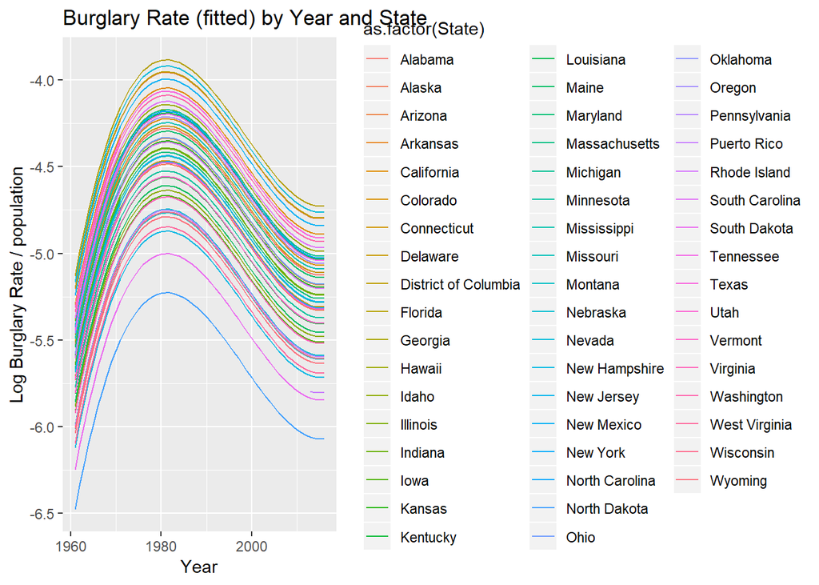

```r
#regression curve fitted values are in fit.lm$fitted.values[,2]
ggplot(fbi) + geom_line(aes(x=Year, y=fit.lm$fitted.values[,2], col=as.factor(State))) +
  ggtitle("Burglary Rate (fitted) by Year and State")+ labs(y="Log Burglary Rate / population")
```

### (d) Construct simultaneous 95% prediction intervals for all the responses in the model at Iowa in 2019 with population 3160000.

I did this using the formula directly, although there’s surely an easy way to do it directly in R.

```r
#prediction vector
#Iowa is the 19th row of coefficients
which(row.names(fit.lm$coefficients)=="as.factor(State)Iowa")
```

```
## [1] 19
```

```r
Y.p <- 2019-1961
predv <- c(1,Y.p,Y.p^2,Y.p^3, rep(0,times=14),1,rep(0, times=51-15))
#prediction. Population was not included in our regression model?
pred <- predv %*% fit.lm$coefficients
pred
```

```
##      Aggravated.assault  Burglary Larceny.theft Legacy.rape
## [1,]          -6.657734 -5.477512     -4.216625   -8.712873
##      Motor.vehicle.theft    Murder   Robbery
## [1,]           -7.157594 -11.10751 -8.044663
```

```r
#if we want to get total number of predicted crimes (with population), convert back to regular scale
pred %>% exp()*3160000
```

```
##      Aggravated.assault Burglary Larceny.theft Legacy.rape
## [1,]           4057.608 13207.91      46604.74    519.6783
##      Motor.vehicle.theft   Murder  Robbery
## [1,]            2461.408 47.39771 1013.758
```

```r
#95% prediction intervals
#need margins of error
p <- ncol(fit.lm$fitted.values)
r <- fit.lm$rank - 1
n <- nrow(fit.lm$fitted.values)
fscale <- (p*(n-r-1))/(n-r-p)
fvalue <- qf(.05, p, n-r-p, lower.tail=F)
betavcov <- (model.matrix(fit.lm) %>% t()) %*% model.matrix(fit.lm)
prederrmat <- t(predv) %*% solve(betavcov) %*% predv
prederr <- 1+prederrmat
varerr <- (n/(n-r-1))*diag(cov(fit.lm$residuals))
merror <- sqrt(fscale*fvalue)*sqrt(prederr%*%varerr)

lbs <- pred - merror
ubs <- pred + merror
pred.intervals <- rbind(ubs,lbs) %>% t()
#on log sca
pred.intervals
```

```
##                           [,1]       [,2]
## Aggravated.assault   -5.562489  -7.752979
## Burglary             -4.649602  -6.305421
## Larceny.theft        -3.550229  -4.883021
## Legacy.rape          -7.650324  -9.775421
## Motor.vehicle.theft  -6.032050  -8.283137
## Murder              -10.061254 -12.153763
## Robbery              -6.898505  -9.190821
```

```r
#on same scale, assuming Iowa's population is 3160000
#but now, the upper bound is in the first column and the lower bound is in the right column
pred.intervals %>% exp()*3160000
```

```
##                           [,1]        [,2]
## Aggravated.assault  12131.9017  1357.09802
## Burglary            30226.6845  5771.35060
## Larceny.theft       90749.0805 23934.14594
## Legacy.rape          1503.8115   179.58739
## Motor.vehicle.theft  7585.7934   798.66810
## Murder                134.9398    16.64849
## Robbery              3189.3679   322.22865
```

### (e) Use `linearHypothesis` function and `anova` function in R to test for the signifcance of the 3 polynomial terms of `Year`. Do the two tests have the same results?

The test using `anova` and `linearHypothesis` return the same Wilks test statistic with the same p-value. THe results agree that we should reject the null hypothesis and conclude that at least 1 of the polynomial terms is significantly non-zero, fitting the data better than the model with no terms for Year-1961.

```r
#new model
fit2.lm <- update(fit.lm, .~ . -Y.1 -Y.2 -Y.3)
#test with ANOVA
anova(fit.lm,fit2.lm,test="Wilks")
```

```
## Analysis of Variance Table
##
## Model 1: cbind(fbi %>% select(5:11) %>% as.matrix()) ~ Y.1 + Y.2 + Y.3 +
##     as.factor(State)
## Model 2: cbind(fbi %>% select(5:11) %>% as.matrix()) ~ as.factor(State)
##   Res.Df Df Gen.var.    Wilks approx F num Df den Df    Pr(>F)
## 1   2800    0.049210
## 2   2803  3 0.082737 0.026136   977.32     21 8023.4 < 2.2e-16 ***
## ---
## Signif. codes:  0 '***' 0.001 '**' 0.01 '*' 0.05 '.' 0.1 ' ' 1
```

```r
#large test statistic, small p-value
#Test with linearhypothesis
#all interaction dummy variables are 0
c<- cbind(rep(0, times=3), diag(3), matrix(0, nrow=3,ncol=51))
newfit <- linearHypothesis(model = fit.lm, hypothesis.matrix = c)
newfit
```

```
##
## Sum of squares and products for the hypothesis:
##                     Aggravated.assault Burglary Larceny.theft Legacy.rape
## Aggravated.assault           668.54570 221.2509      394.0707    661.9414
## Burglary                     221.25095 318.7555      233.9915    195.0024
## Larceny.theft                394.07069 233.9915      280.0576    381.0444
## Legacy.rape                  661.94139 195.0024      381.0444    658.0141
## Motor.vehicle.theft          242.29765 225.6536      215.2130    228.3965
## Murder                        97.86268 192.4499      123.2959     80.7334
## Robbery                      496.81127 284.9033      342.4432    479.7900
##                     Motor.vehicle.theft    Murder  Robbery
## Aggravated.assault             242.2977  97.86268 496.8113
## Burglary                       225.6536 192.44994 284.9033
## Larceny.theft                  215.2130 123.29588 342.4432
## Legacy.rape                    228.3965  80.73340 479.7900
## Motor.vehicle.theft            203.7902 125.13750 248.1275
## Murder                         125.1375 119.56343 151.8425
## Robbery                        248.1275 151.84249 428.6842
##
## Sum of squares and products for error:
##                     Aggravated.assault  Burglary Larceny.theft Legacy.rape
## Aggravated.assault           231.24691  38.41518     19.035090    72.11159
## Burglary                      38.41518 132.13539     76.686098    51.94489
## Larceny.theft                 19.03509  76.68610     85.608781    31.34367
## Legacy.rape                   72.11159  51.94489     31.343666   217.64596
## Motor.vehicle.theft           52.55590  87.42137     56.529256    30.76870
## Murder                        60.86878  28.42973      8.280175    42.15882
## Robbery                       66.40140 105.49402     77.452943    94.01645
##                     Motor.vehicle.theft     Murder   Robbery
## Aggravated.assault             52.55590  60.868779  66.40140
## Burglary                       87.42137  28.429731 105.49402
## Larceny.theft                  56.52926   8.280175  77.45294
## Legacy.rape                    30.76870  42.158823  94.01645
## Motor.vehicle.theft           244.21818  53.184736 123.66869
## Murder                         53.18474 211.022199  65.78259
## Robbery                       123.66869  65.782590 253.24603
##
## Multivariate Tests:
##                  Df test stat  approx F num Df  den Df     Pr(>F)
## Pillai            3  1.813697  610.6727     21 8388.00 < 2.22e-16 ***
## Wilks             3  0.026136  977.3155     21 8023.41 < 2.22e-16 ***
## Hotelling-Lawley  3 10.259345 1364.3301     21 8378.00 < 2.22e-16 ***
## Roy               3  7.396180 2954.2455      7 2796.00 < 2.22e-16 ***
## ---
## Signif. codes:  0 '***' 0.001 '**' 0.01 '*' 0.05 '.' 0.1 ' ' 1
```

```r
#Wilks Statistic is the same
```

### (f) Use principal components analysis to reduce the dimensionality of the crimes into fewer dimensions. How many principal components should be chosen? Explain the meaning of the leading principal components. Notice that the data need to be centered separately for each state first.

The first principal component is just a weighted average of the variables (overall crime rate). The second is a contrast between centered assault/rape and the rest of the variables (pretty much contrast between theft cases and violent cases, except for murder). The third PC is another contrast between violent crimes (assault/murder) and non-violent/theft crimes, except for rape (very similar to the 2nd PC).

```r
#center the response variables
fbi.av <- fbi[,c(1,5:11)] %>% group_by(State) %>% summarise_all(mean)
head(fbi.av)
```

```
## # A tibble: 6 x 8
##   State Aggravated.assa~ Burglary Larceny.theft Legacy.rape
##   <chr>            <dbl>    <dbl>         <dbl>       <dbl>
## 1 Alab~            -5.88    -4.71         -3.95       -8.33
## 2 Alas~            -5.79    -4.91         -3.65       -7.48
## 3 Ariz~            -5.84    -4.38         -3.38       -8.06
## 4 Arka~            -6.01    -4.76         -3.95       -8.21
## 5 Cali~            -5.74    -4.47         -3.66       -8.05
## 6 Colo~            -6.15    -4.65         -3.58       -7.90
## # ... with 3 more variables: Motor.vehicle.theft <dbl>, Murder <dbl>,
## #   Robbery <dbl>
```

```r
fbij <- left_join(fbi, fbi.av, by=c('State'='State'))
fbi.centered <- cbind(fbi[,1:4],fbi[,5:11]-fbij[,15:21],fbi[,12:14]) %>% data.frame()
head(fbi.centered)
```

```
##     State Abb Year Population Aggravated.assault   Burglary Larceny.theft
## 1 Alabama  AL 1961    3302000         -0.7691987 -0.9807928    -1.2210057
## 2 Alabama  AL 1962    3358000         -0.8490671 -0.9525027    -1.1127443
## 3 Alabama  AL 1963    3347000         -0.6716328 -0.8758817    -1.0384510
## 4 Alabama  AL 1964    3407000         -0.5338988 -0.6622634    -0.9010693
## 5 Alabama  AL 1965    3462000         -0.6232874 -0.6473116    -0.8659307
## 6 Alabama  AL 1966    3517000         -0.4479520 -0.5397092    -0.7975515
##   Legacy.rape Motor.vehicle.theft      Murder   Robbery Y.1 Y.2 Y.3
## 1  -1.1529438          -1.1426844  0.26992265 -1.588783   0   0   0
## 2  -1.3146950          -1.0597187 -0.04793636 -1.425928   1   1   1
## 3  -1.4384135          -0.9768619  0.02854818 -1.329026   2   4   8
## 4  -0.7297404          -0.8015408 -0.06242294 -1.166084   3   9  27
## 5  -0.8243291          -0.8113229  0.14470629 -1.182098   4  16  64
## 6  -0.9135704          -0.6085982  0.10070118 -1.072934   5  25 125
```

```r
#PC analysis
fbi.centered.pc <- prcomp(fbi.centered[,5:11])
fbi.centered.pc
```

```
## Standard deviations (1, .., p=7):
## [1] 0.9844394 0.4687411 0.2734183 0.2453594 0.2125781 0.1895412 0.1226197
##
## Rotation (n x k) = (7 x 7):
##                           PC1        PC2         PC3         PC4
## Aggravated.assault  0.5027270  0.4098666  0.32903171 -0.54707779
## Burglary            0.2839916 -0.5116312 -0.11280993  0.21254754
## Larceny.theft       0.3288971 -0.1101851 -0.24744546  0.08798295
## Legacy.rape         0.4924305  0.4590238 -0.07298762  0.41749764
## Motor.vehicle.theft 0.2819515 -0.4202403 -0.26706336 -0.60954795
## Murder              0.1627396 -0.3844397  0.84385861  0.16582058
## Robbery             0.4582274 -0.1516690 -0.17039778  0.27283508
##                             PC5         PC6         PC7
## Aggravated.assault   0.39290509  0.06386387 -0.11517774
## Burglary             0.47648748 -0.36454675 -0.48963774
## Larceny.theft        0.29723186 -0.18650739  0.82920679
## Legacy.rape         -0.44077920 -0.39457650 -0.13115225
## Motor.vehicle.theft -0.53244000 -0.13071519 -0.02123987
## Murder              -0.22106900 -0.04054505  0.18871322
## Robbery             -0.05990277  0.80859204 -0.07836033
```

```r
csums <- cumsum(fbi.centered.pc$sdev^2) / sum(fbi.centered.pc$sdev^2)
csums
```

```
## [1] 0.6825041 0.8372408 0.8898889 0.9322857 0.9641104 0.9894112 1.0000000
```

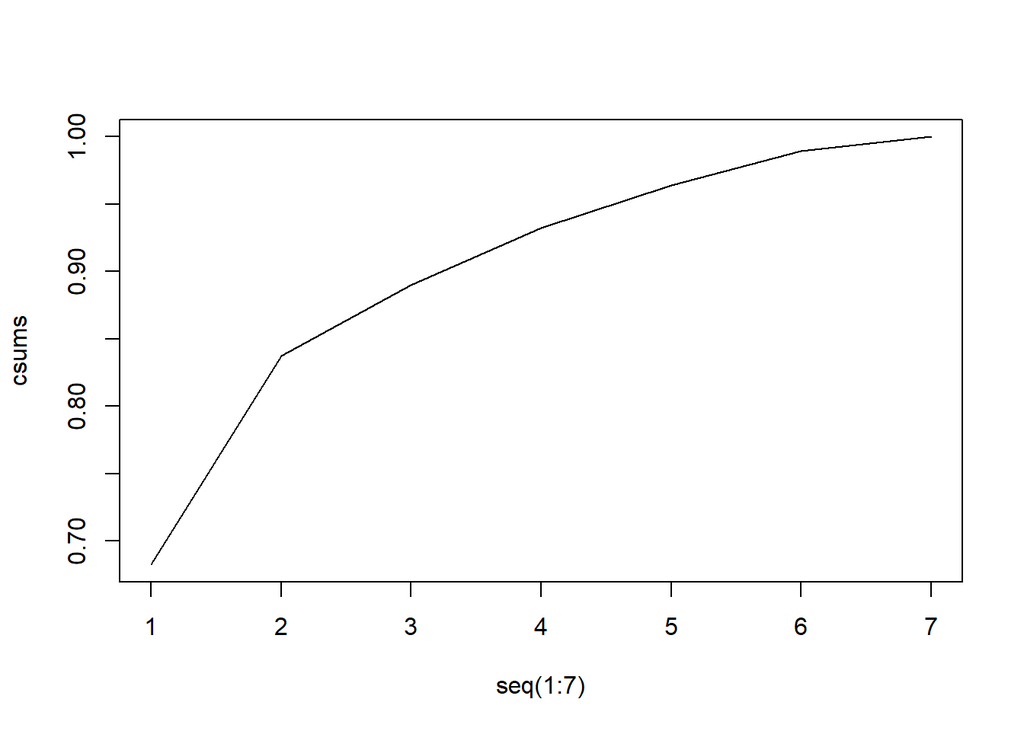

```r
plot(y=csums,x=seq(1:7), type='l')
```

```r
# I will use 3 pcs, although we could justify any between 2 and 4
```

### (h) Is there any distinctiveness of the states `California`, `Iowa`, `Illinois`, `District of Columbia` and `New York` in the first two principal components? (Transformed versions of sample means of each state need to be added back on the PC scores.)

We can see that Iowa has a much lower overall crime rate (pc1), but much higher rate of violent crime vs. nonviolent/theft crimes, while District of Columbia has a much higher overall crime rate and somewhat lower proportion of Assault/rape vs. theft crimes.The rest of the states are similar, although it is clear that they are different over time.

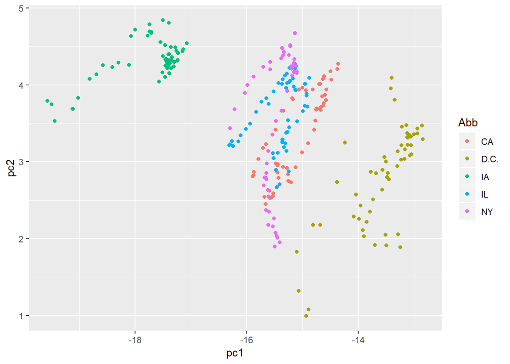

```r
#looking only at the first two PCs
#Transform data by PCs and un-center the data
fbi.pc1 <- (as.matrix(fbi.centered.pc$x) + as.matrix(fbij[,15:21])) %*%fbi.centered.pc$rotation[,1]
fbi.pc2 <- (as.matrix(fbi.centered.pc$x) + as.matrix(fbij[,15:21])) %*%fbi.centered.pc$rotation[,2]
fbi.tr <- data.frame(Abb=fbi$Abb, pc1=fbi.pc1, pc2=fbi.pc2)
fbi.tr <- fbi.tr %>% filter(Abb%in% c("CA", "IA","IL","D.C.","NY"))
ggplot(fbi.tr) + geom_point(aes(x=pc1,y=pc2, col=Abb))
```

## 2. The United States Postal Service has had a long-term project to automating the recognition of handwritten digits for zip codes. The data on different numbers of specimens for each digit are available in Canvas. Each observation is in the form of a 256-dimensional vector of pixel intensities. These form a $16 \times 16$ image of pixel intensities for each letter. The objective is to distinguish one digit from another.

### (a) We will see whether the digits are distinguishable. To do so, we will first prepare the dataset by rooting out those pixels (coordinates) which do not contribute to categorization. Do so, using univariate anova test for each coordinate. Choose the 100 most significant coordinates (in terms of the p-value for the above test).

```r
#pixels
ziptrain <- read_delim("ziptrain.dat", delim=" ", col_names=F) %>% as.data.frame()
#digits
zipdigit <- read_delim('zipdigit.dat', delim=" ", col_names=F) %>% as.matrix
#univariate anovas for each
#use a loop
i=0
pvals <- matrix(nrow=256,ncol=2)
repeat{
  i=i+1
  pix <- lm(c(ziptrain[,i])~as.factor(zipdigit[,1]))
  pvals[i,] <- c(i,anova(pix)$`Pr(>F)`[1])
  if(i==256){break}
}
#sort the pvalues, keep the top 100
top100p <- pvals %>% data.frame %>% arrange(X2)
top100p <- top100p[1:100,1]
top100p %>% head()
```

```
## [1] 104 105 120 121 136 152
```

### (b) We will now use principal components to reduce dimensionality of the original dataset. It would be preferred to remove the effect of the digit-specific means before performing the principal components analysis. Use the principal components and determine the number of components needed to explain at least 80% of the total variation in the data, at the 5% level of significance.

Based on these results, we would need 16 principal components to describe 80% of the variation for 5% significance level, on the centered data.

```r
#center the data first
#use only the best 100
ziptrain.t <- ziptrain[,top100p]
ziptrain.m <- ziptrain.t %>% apply(2,mean)
ziptrain.c <- sweep(ziptrain.t, MARGIN=2,ziptrain.m)
#PCs
zip.pc <- prcomp(ziptrain.c)
zip.pc %>% summary()
```

```
## Importance of components:
##                           PC1    PC2     PC3     PC4     PC5     PC6
## Standard deviation     4.2998 2.8840 2.00514 1.93850 1.82061 1.73757
## Proportion of Variance 0.2707 0.1218 0.05888 0.05503 0.04854 0.04421
## Cumulative Proportion  0.2707 0.3926 0.45143 0.50646 0.55500 0.59921
##                            PC7     PC8     PC9    PC10    PC11    PC12
## Standard deviation     1.48373 1.37482 1.33089 1.24117 1.13352 1.07885
## Proportion of Variance 0.03224 0.02768 0.02594 0.02256 0.01882 0.01704
## Cumulative Proportion  0.63145 0.65913 0.68507 0.70763 0.72645 0.74349
##                           PC13    PC14   PC15    PC16    PC17    PC18
## Standard deviation     1.04103 0.96167 0.9531 0.87107 0.85643 0.84932
## Proportion of Variance 0.01587 0.01354 0.0133 0.01111 0.01074 0.01056
## Cumulative Proportion  0.75936 0.77291 0.7862 0.79732 0.80806 0.81863
##                           PC19    PC20   PC21    PC22    PC23    PC24
## Standard deviation     0.79827 0.77847 0.7482 0.71130 0.70856 0.69834
## Proportion of Variance 0.00933 0.00887 0.0082 0.00741 0.00735 0.00714
## Cumulative Proportion  0.82796 0.83683 0.8450 0.85244 0.85979 0.86694
##                           PC25    PC26    PC27    PC28    PC29    PC30
## Standard deviation     0.66765 0.64134 0.62087 0.60946 0.59512 0.57018
## Proportion of Variance 0.00653 0.00602 0.00565 0.00544 0.00519 0.00476
## Cumulative Proportion  0.87346 0.87949 0.88513 0.89057 0.89576 0.90052
##                           PC31   PC32    PC33    PC34    PC35    PC36
## Standard deviation     0.56988 0.5483 0.53221 0.52361 0.51442 0.49646
## Proportion of Variance 0.00476 0.0044 0.00415 0.00401 0.00388 0.00361
## Cumulative Proportion  0.90527 0.9097 0.91382 0.91784 0.92172 0.92532
##                           PC37    PC38    PC39    PC40    PC41    PC42
## Standard deviation     0.47907 0.46573 0.46254 0.45386 0.43060 0.42355
## Proportion of Variance 0.00336 0.00318 0.00313 0.00302 0.00272 0.00263
## Cumulative Proportion  0.92869 0.93186 0.93499 0.93801 0.94073 0.94335
##                           PC43   PC44    PC45   PC46    PC47    PC48
## Standard deviation     0.41913 0.4047 0.39709 0.3877 0.38391 0.37381
## Proportion of Variance 0.00257 0.0024 0.00231 0.0022 0.00216 0.00205
## Cumulative Proportion  0.94593 0.9483 0.95063 0.9528 0.95499 0.95704
##                           PC49   PC50    PC51    PC52    PC53    PC54
## Standard deviation     0.36236 0.3504 0.34297 0.33732 0.33223 0.32583
## Proportion of Variance 0.00192 0.0018 0.00172 0.00167 0.00162 0.00155
## Cumulative Proportion  0.95896 0.9608 0.96248 0.96415 0.96577 0.96732
##                           PC55    PC56   PC57    PC58   PC59    PC60
## Standard deviation     0.31853 0.31510 0.3090 0.30347 0.2983 0.29277
## Proportion of Variance 0.00149 0.00145 0.0014 0.00135 0.0013 0.00126
```

[output cut: 14 more lines]

```
## Standard deviation     0.2029 0.19867 0.19348 0.19015 0.18601 0.17947
## Proportion of Variance 0.0006 0.00058 0.00055 0.00053 0.00051 0.00047
## Cumulative Proportion  0.9921 0.99271 0.99326 0.99379 0.99430 0.99477
##                           PC85    PC86    PC87    PC88    PC89    PC90
## Standard deviation     0.17861 0.17271 0.16905 0.16348 0.15985 0.15844
## Proportion of Variance 0.00047 0.00044 0.00042 0.00039 0.00037 0.00037
## Cumulative Proportion  0.99524 0.99567 0.99609 0.99648 0.99686 0.99723
##                           PC91    PC92    PC93    PC94    PC95    PC96
## Standard deviation     0.15550 0.15321 0.15038 0.14844 0.14052 0.13941
## Proportion of Variance 0.00035 0.00034 0.00033 0.00032 0.00029 0.00028
## Cumulative Proportion  0.99758 0.99792 0.99825 0.99858 0.99887 0.99915
##                           PC97    PC98    PC99   PC100
## Standard deviation     0.13502 0.12361 0.11445 0.10645
## Proportion of Variance 0.00027 0.00022 0.00019 0.00017
## Cumulative Proportion  0.99942 0.99964 0.99983 1.00000
```

```r
cumsum(zip.pc$sdev^2) / sum(zip.pc$sdev^2)
```

```
##   [1] 0.2707482 0.3925502 0.4514294 0.5064600 0.5550007 0.5992146 0.6314538
##   [8] 0.6591338 0.6850732 0.7076329 0.7264490 0.7434938 0.7593648 0.7729081
##  [15] 0.7862102 0.7973219 0.8080631 0.8186268 0.8279587 0.8368334 0.8450318
##  [22] 0.8524411 0.8597934 0.8669352 0.8734630 0.8794864 0.8851315 0.8905710
##  [29] 0.8957576 0.9005186 0.9052746 0.9096767 0.9138247 0.9178397 0.9217150
##  [36] 0.9253245 0.9286854 0.9318619 0.9349949 0.9380115 0.9407268 0.9433540
##  [43] 0.9459265 0.9483246 0.9506338 0.9528350 0.9549933 0.9570397 0.9589626
##  [50] 0.9607610 0.9624836 0.9641499 0.9657664 0.9673211 0.9688070 0.9702610
##  [57] 0.9716595 0.9730082 0.9743115 0.9755667 0.9768130 0.9779528 0.9790692
##  [64] 0.9800967 0.9810863 0.9820277 0.9829601 0.9838666 0.9847580 0.9856399
##  [71] 0.9864796 0.9872929 0.9880942 0.9888136 0.9895284 0.9902210 0.9908884
##  [78] 0.9915335 0.9921363 0.9927143 0.9932625 0.9937920 0.9942986 0.9947703
##  [85] 0.9952375 0.9956743 0.9960928 0.9964842 0.9968584 0.9972260 0.9975801
##  [92] 0.9979238 0.9982550 0.9985777 0.9988669 0.9991515 0.9994185 0.9996422
##  [99] 0.9998341 1.0000000
```

```r
#around 16-20

# Test for the PC proportions
#want the largest # of PCs where we fail to reject at 5% significance
#16 fails to reject, but 15 rejects
#We want the first 16 PCs
PCs.proportion.variation.enuff(zip.pc$sdev^2, 15, 0.8, nobs=nrow(ziptrain))
```

```
## [1] 1.684521e-09
```

```r
PCs.proportion.variation.enuff(zip.pc$sdev^2, 16, 0.8, nobs=nrow(ziptrain))
```

```
## [1] 0.1133926
```

### (c) Use `ggplot` to display the leading components (using color or characters for each digit).

The plot along the 2 leading components shows that 1 and 0 vary alot from the rest of the digits, as does 6, indicating that these digits are more distinct from the other digits.

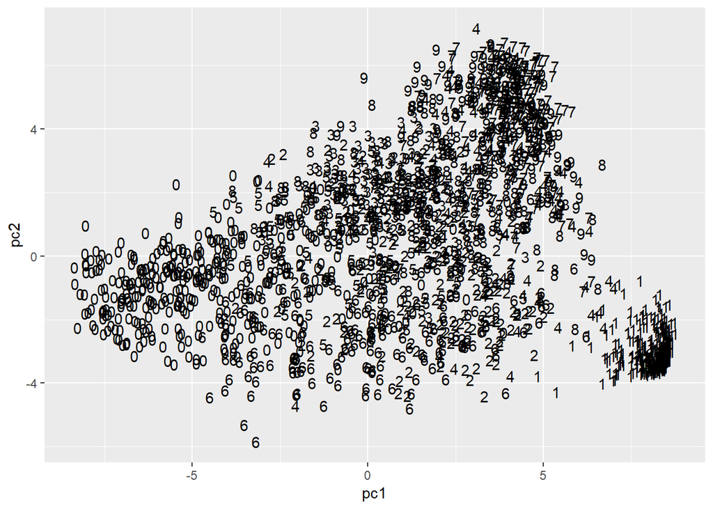

```r
#transform by principal components
ziptransf <- data.frame(zipdig=zipdigit[,1], pc1=as.matrix(ziptrain.t) %*% zip.pc$rotation[,1], pc2=as.matrix(ziptrain.t) %*% zip.pc$rotation[,2])
#plot using ggplot
#with characters, does not look very good
ggplot(ziptransf)+ geom_text(aes(y=pc2,x=pc1, label=as.factor(zipdig)))
```

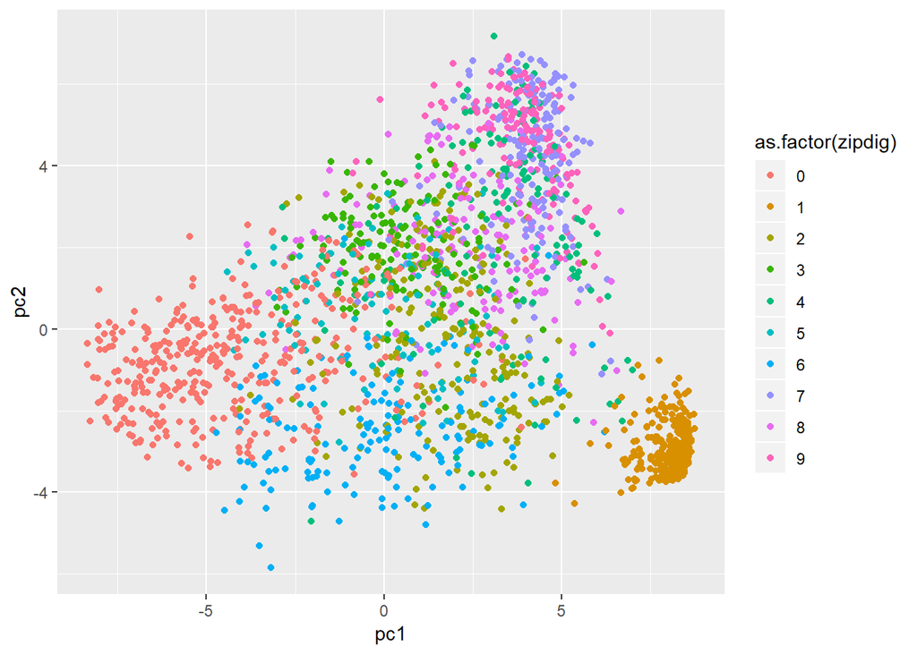

```r
#try with colors
ggplot(ziptransf) + geom_point(aes(y=pc2,x=pc1, col=as.factor(zipdig)))
```